# Part II - Effects of Loan Characteristics on Borrower's APR

## by Festus Sambu

## Investigation Overview

In this investigation, I wanted to look at the characteristics of loans that could be used to predict their borrower APR. The main focus was on the original loan amount, borrower's CreditScoreRating, loan term, borrower's loan Status.

## Dataset Overview

The loans dataset contains 113k+ Prosper loans from the period 2005-2014 and 81 variables. Prosper is a US peer-to-peer landing company founded in 2005, so the dataset covers the first years of their business. The data collection went through changes in 2009, which we kept in mind during the investigation.

Distribution of Borrower APR

The distribution of APR looks multimodal. A small peak centered at 0.1, a large peak centered at 0.2. There is also a small peak centered 0.3. Additionally, there is a very shape peak between 0.35 and 0.36. Only very few loans have APR greater than 0.43.

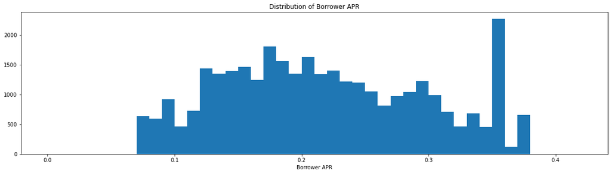

## Borrower's APR vs (Loan Original Amount, MonthlyLoanPayment, CreditScoreRangeLower)

Borrower's APR tend to have a negative correlation with Loan Original Amount, MonthlyLoanPayment, CreditScoreRangeLower variables

[figure not shown]

## Borrower APR vs. CreditRiskScore

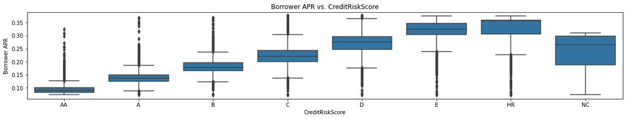

## Borrower APR by CreditRiskScore and Term

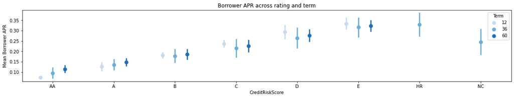